# Year 1 Pennsylvania Data Exploration

Jake Eisaguirre

2022-09-20

```r
knitr::opts_chunk$set(echo = TRUE, warning = F)

if (!require(librarian)){
  install.packages("librarian")
  library(librarian)
}

librarian::shelf(here, tidyverse, janitor, scales, viridis, ggpubr, kableExtra, broom, stringr, forcats)
```

$~$

# Visual Encounter Surveys

### Load and Wrangle VES Data

$~$

#### Load data

```r
ves <- read_csv(here("data", "ves.csv")) %>%
  clean_names()
```

$~$

#### VES wrangling

```r
visual <- ves %>%
  group_by(site, species_ves) %>%
  summarise(count = sum(count),
            species_ves = species_ves) %>%
  mutate(repeat_id = cur_group_id(),
         species_ves = as.factor(species_ves)) %>%
  filter(!duplicated(repeat_id)) %>%
  select(!repeat_id)

visual$scaled_count<- ((visual$count/ sum(visual$count))*100) %>%
  round(digits = 2)
```

$~$

### Visualize All VES Data

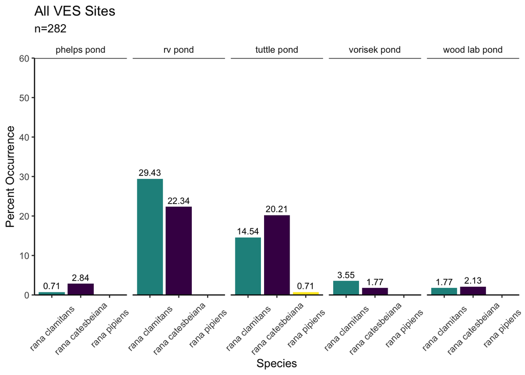

```r
ggplot(data = visual, aes(fill = species_ves, x = reorder(species_ves, -scaled_count), y = scaled_count)) +
  geom_col() +
  geom_text(aes(label = scaled_count), vjust = -0.5, size = 3) +
  theme_classic()+
  facet_grid(~site) +
  theme(axis.text.x = element_text(angle = 45, vjust = 0.5),
        strip.background = element_blank(),
        legend.position = "none") +
  scale_fill_viridis_d(name = "Species") +
  scale_y_continuous(expand = c(0,0), limits = c(0,60)) +
  ylab("Percent Occurrence") +
  xlab("Species") +
  labs(title = "All VES Sites",
       subtitle = "n=282") +
  annotate("segment",x=Inf,xend=-Inf,y=Inf,yend=Inf,color="black",lwd=0.5)
```

###### **Interpretation**: From this figure we can see the percent occurrence per species at each unique site from the VES. There were 5 unique sites within the VES and 3 unique species recorded in the VES. It appears Rana clamitans is the most occurring species and Rana pipiens the least occurring species in the VES.

$~$

#### VES wrangling - Tuttle Pond and Wood Lab Pond (repeated sites)

```r
ves_repeat_survs <- ves %>%
  group_by(site, date, species_ves) %>%
  summarise(count = sum(count),
            species_ves = species_ves) %>%
  mutate(repeat_id = cur_group_id()) %>%
  filter(!duplicated(repeat_id),
         site %in% c("tuttle pond", "wood lab pond")) %>%
  select(!repeat_id) %>%
  mutate(site = as.factor(site),
         date = as.factor(date),
         species_ves = as.factor(species_ves))


tuttle <- ves_repeat_survs %>%
  filter(site == "tuttle pond")

tuttle$scaled_count<- ((tuttle$count/ sum(tuttle$count))*100)


wood <- ves_repeat_survs %>%
  filter(site == "wood lab pond")

wood$scaled_count<- ((wood$count/ sum(wood$count))*100)
```

$~$

### Visualize Tuttle Pond

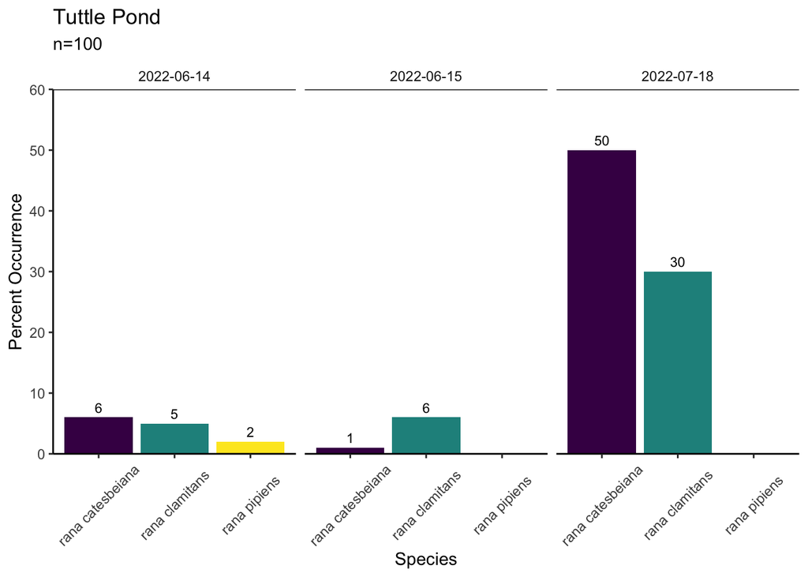

```r
ggplot(data = tuttle, aes(fill = species_ves, x = fct_infreq(species_ves), y = scaled_count)) +
  geom_col() +
  geom_text(aes(label = scaled_count), vjust = -0.5, size = 3) +
  theme_classic()+
  facet_wrap(~date) +
  theme(axis.text.x = element_text(angle = 45, vjust = 0.5),
        strip.background = element_blank(),
        legend.position = "none") +
  scale_fill_viridis_d(name = "Species") +
  scale_y_continuous(expand = c(0,0), limits = c(0,60)) +
  ylab("Percent Occurrence") +
  xlab("Species") +
  labs(title = "Tuttle Pond",
       subtitle = "n=100") +
  annotate("segment",x=Inf,xend=-Inf,y=Inf,yend=Inf,color="black",lwd=0.5)
```

###### **Interpretation**: Tuttle Pond was one of two repeated sites, the other being Woods Lab Pond. VES for Tuttle Pond was conducted during 3 unique dates with trends eliciting the date when the survey was conducted may have an impact on the species occurrence. A total of 100 frogs were observed during those 3 dates.

$~$

### Visualize Wood Lab Pond

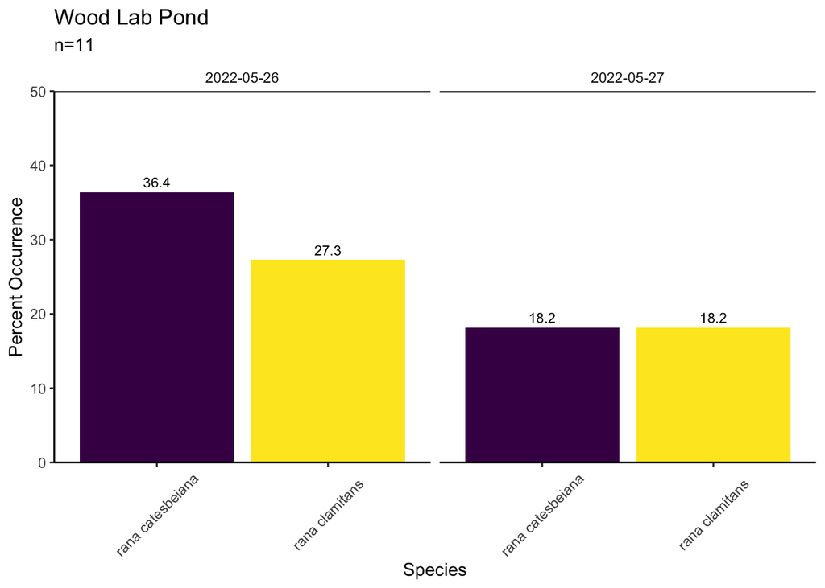

```r
ggplot(data = wood, aes(fill = species_ves, x = fct_infreq(species_ves), y = scaled_count)) +
  geom_col() +
  geom_text(aes(label = round(scaled_count, 1)), vjust = -0.5, size = 3) +
  theme_classic()+
  facet_wrap(~date) +
  theme(axis.text.x = element_text(angle = 45, vjust = 0.5),
        strip.background = element_blank(),
        legend.position = "none") +
  scale_fill_viridis_d(name = "Species") +
  scale_y_continuous(expand = c(0,0), limits = c(0,50)) +
  ylab("Percent Occurrence") +
  xlab("Species") +
  labs(title = "Wood Lab Pond",
       subtitle = "n=11") +
  annotate("segment",x=Inf,xend=-Inf,y=Inf,yend=Inf,color="black",lwd=0.5)
```

###### **Interpretation**: Wood Lab Pond had 2 unique dates when a VES was conducted. A total of 11 frogs were observed during the 2 dates of surveys. Due to a small sample size no further analysis was conducted on this specific site.

$~$